# Jews_Sentiments_FinalDraft

Theis André Schwartz og Tristan Alexander Michael Cooper

2024-05-20

This version of the assignment utilizes R 4.4.0, the newest version of the program pr.2024/05/14 on posit.cloud. We recommend using posit.cloud when reviewing this code, as that is the platfor, we utilized for this product.

Download links and install packages for the project. This will be visible in the Rmarkdown document, but will be hidden with the ‘echo function’.

```
## Skipping install of 'Sentida' from a github remote, the SHA1 (15f40e2c) has not changed since last install.
##   Use `force = TRUE` to force installation
```

```
## Skipping install of 'Sentida' from a github remote, the SHA1 (15f40e2c) has not changed since last install.
##   Use `force = TRUE` to force installation
```

Loading every package we will be using.

```
## here() starts at /cloud/project
##
## Using poppler version 0.86.1
```

We will be starting off by entering the data from 1800-1839, using the search string “(jødisk* OR jøde* OR mos*it) AND py:[1800 TO 1839]”

```r
jewsearlycent <- read_csv("https://labs.statsbiblioteket.dk/labsapi/api/aviser/export/fields?query=%28j%C3%B8disk%2A%20OR%20j%C3%B8de%2A%20OR%20mos%2Ait%29%20AND%20py%3A%5B1800%20TO%201839%5D&fields=link&fields=recordID&fields=timestamp&fields=pwa&fields=fulltext_org&fields=familyId&fields=lplace&max=-1&structure=header&structure=content&format=CSV")
```

Next, we will create a seperate column for ‘year’, splitting the specific dates from the year of publication.

```r
#Split years

jewsearlycent %>%
  mutate(year=year(timestamp)) -> jewishyear
```

But before we move on, we will briefly take a moment to calculate the average accuracy of the OCR scannings, from our dataset. We will do this with the following command.

```r
#Calculate mean() of pwa.

mean(jewishyear$pwa)
```

```
## [1] 48.57315
```

We can see here, that the accuracy of the OCR scannings average at around 48.57 out of 100, or 48%. This will be acknowlegded and taken into account in the final report.

Now, we will run a series of unnest and antijoin commands, to tidy up our dataset. First, we will unnest the words and seperate them individually.

```r
#Tidying

jewishyear %>%
  unnest_tokens(word, fulltext_org) -> jewish_tidy
```

Next, we will load our stopword list for danish words from the 1800s, using a stopword package created by Max Odsbjerg Pedersen, and apply it to the dataset.

```r
#Loading stopwords by Max Odsbjerg Pedersen.

stopord_1800 <- read_csv("https://gist.githubusercontent.com/maxodsbjerg/1537cf14c3d46b3d30caa5d99f8758e9/raw/9f044a38505334f035be111c9a3f654a24418f6d/stopord_18_clean.csv")
jewish_tidy %>%
  anti_join(stopord_1800) %>%
  group_by(familyId, lplace, timestamp) %>%
  count(word, sort = TRUE) -> jewish_tidy_stop
```

Afterwards, we will apply the Sentida Sentiment Tool to our dataset, which will be run, but only visibly included in the Rmarkdown.

Now, we will be making graphs to show the sentiment across the different newspapers.

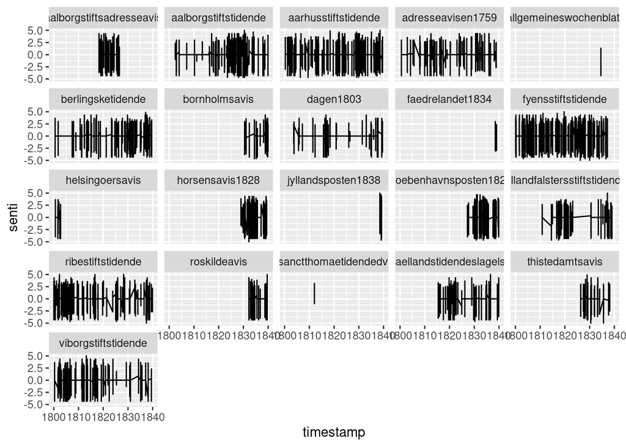

```r
jewishplotsent = ggplot(data= jewish_no_numeric, aes(x = timestamp, y = senti)) +
  geom_line() +
  facet_wrap(facets= vars(familyId))

jewishplotsent
```

As we have a lot of information about the jewish feuds from 1813 to 1821, we want to create a subset of data, containing this time interval. This was done using a tutorial from neonscience.org: https://www.neonscience.org/resources/learning-hub/tutorials/dc-subset-data-no-data-values-r

```r
jewish_feuds <- subset(jewish_no_numeric,
                      timestamp >=as.POSIXct("1813-1-1 00:00",
                                            tz = "Denmark") &
                      timestamp <=as.POSIXct("1821-12-31 00:00",
                                            tz = "Denmark"))
```

```r
jewish_feud_senti = ggplot(data = jewish_feuds, aes(x = timestamp, y = senti, color = familyId)) +
  geom_point(alpha = 0.3) +
  facet_wrap(vars(familyId))+
  labs(title = "sentiment towards jewish people in danish newspapers around the time of the jewish feuds (1813-1821)", x = "Year", y = "sentiment")

sentida(jewish_feuds$word, output="mean")
```

```
## [1] 0.1244426
```

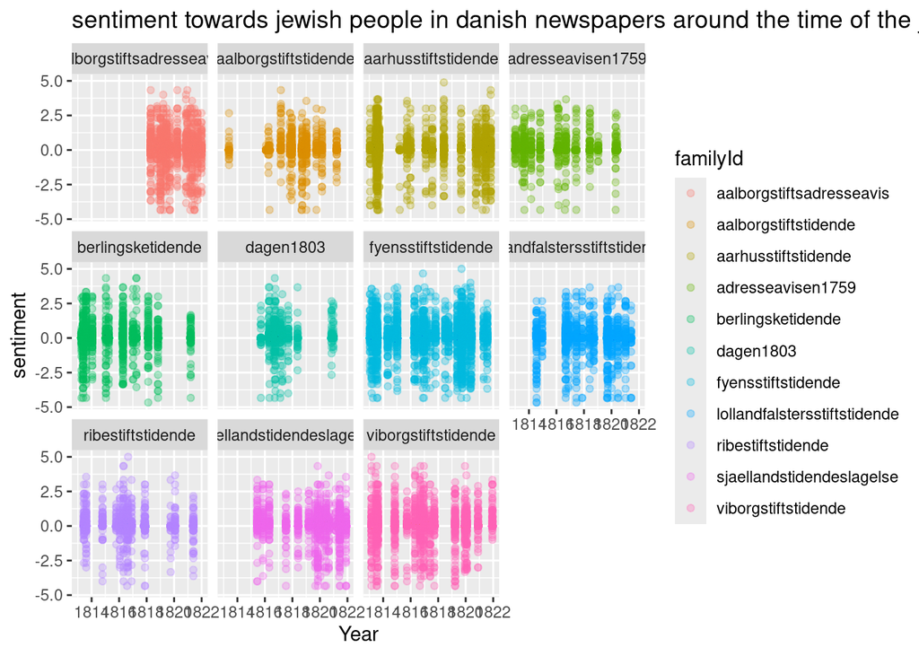

```r
jewish_feud_senti
```

```r
ggsave("Feudssentiment.jpeg", width = 12, height = 8)
```

Thus, we have applied Sentiment analysis to our dataset, visualized graphs and are now ready to analyze them.